# POLS 2972Q

Quantitative Analysis in Political Science

Lecture 20 |

Probability

## Plan for Today

- Continue our discussion of probability and distributions
- Probability Distributions
  - The Standard Normal Distribution
- Population Parameters
- Sample Statistics

## The Standard Normal Distribution

- Normal distribution with mean 0 and variance 1 (and standard deviation = 1)
- In mathematical notation, we refer to the standard normal random variable as Z and write it as:

Z ~ N(0,1)

- Note this Z has nothing to do with confounding variables
- Z has two useful properties. . .
- First, since Z is symmetric and centered at 0:

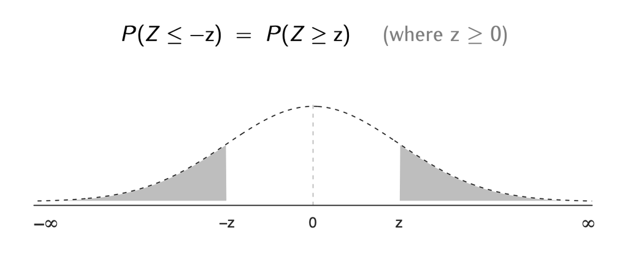

Second, about 95% of the observations of Z are between -1.96 and 1.96:

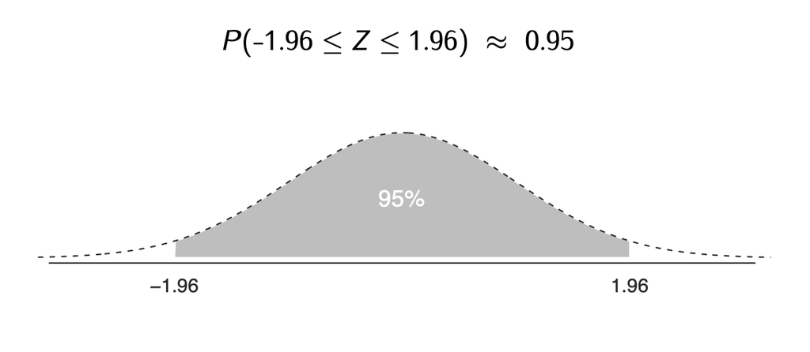

## How to Transform A Normal Random Variable Into the Standard Normal Random Variable

if X ~ N$(\mu, \sigma^2)$, $\frac{X - \mu}{\sigma}$ ~ N(0,1)

## Population Parameters vs. Sample Statistics

- When we analyze data, we are usually interested in the value of a **parameter** at the population level
  - Example: proportion of candidate A supporters among all voters in a country
- We typically only have access to **statistics** from a small sample of observations drawn from the target population
  - Example: proportion of supporters among the voters who responded to a survey
- The sample statistics differ from the population parameters because the sample contains noise
  - This noise comes from **sampling variability**

## Sample Variability

- Refers to the fact that the value of a statistic varies from one sample to another because each sample contains a different set of observations drawn from the target population
- This is true even when the samples are drawn using the exactly same method such as random sampling
- Smaller sample size generally leads to greater sampling variability

## What proportion of US voters supports candidate A?

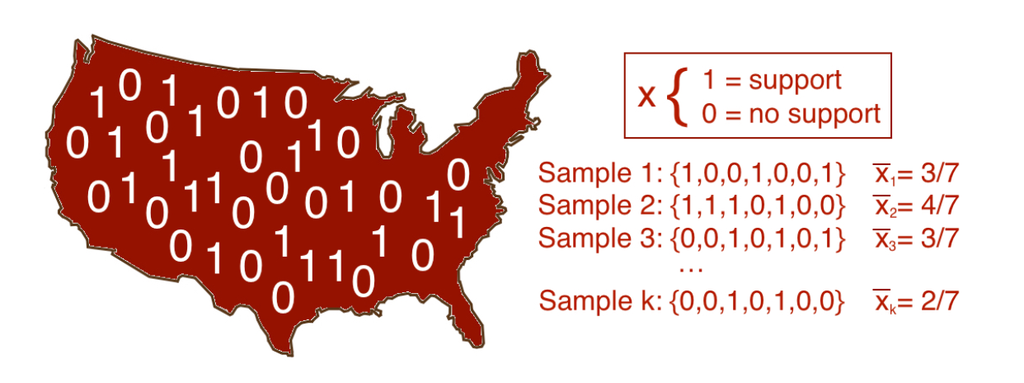

- If we draw a random sample from the population over and over again, we will get different proportions of support ($\bar{X}$)
- Again, this is due to sampling variability
- How can we figure out what we want to know: the proportion of support among the whole population?
- The two large sample theorems—the law of large numbers and the central limit theorem—help us understand the relationship between population parameters and sample statistics
  - Central Limit Theorem: as the sample size increases, the standardized sample mean of X can be approximated by the stand normal distribution
  - Law of Large Numbers: as the sample size increases, the sample mean of X approximates the population of X
- As we will see next class, we can use them to draw conclusions about population parameters using data from just a sample
- Let’s define the different terms:
- Population Parameters:
  - Expectation or Population Mean, $\mathbb{E}(X)$: the average value of the random variable X at the population level
  - Population Variance, $\mathbb{V}(X)$: the variance of the random variable X at the population level
- Sample Statistics:
  - Sample mean: $\bar{x}$
  - Sample variance: var(X)
- $\bar{x}$ and var(X) vary from sample to sample
- $\mathbb{E}(X)$ and $\mathbb{V}(X)$ are population charateristics

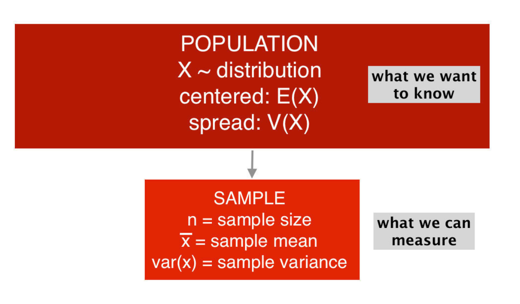

## The Law of Large Numbers

- As the sample size increases, the sample mean of X approximates the population mean of X

as n increases, $\bar{x} = \frac{\sum_{i = 1}^{n} X_i}{n} \approx \mathbb{E}(X)$

- Example in the book: Proportion of support in a sample of 1 million observations is likely to be closer to the proportion of support in the whole population than the proportion of support in a sample of 1 thousand observations

## The Central Limit Theorem

- As the sample size increases, the standardized sample mean of X can be approximated by the standard normal distribution

as n increases, $\frac{\bar{X} - \mathbb{E}(X)}{\sqrt{\mathbb{V}(X)/n}} \approx$ N(0,1)

- Example in the book: Even when the random variable we draw from is binary, if we draw repeated large samples, the standardized sample means will approximately follow a standard normal distribution

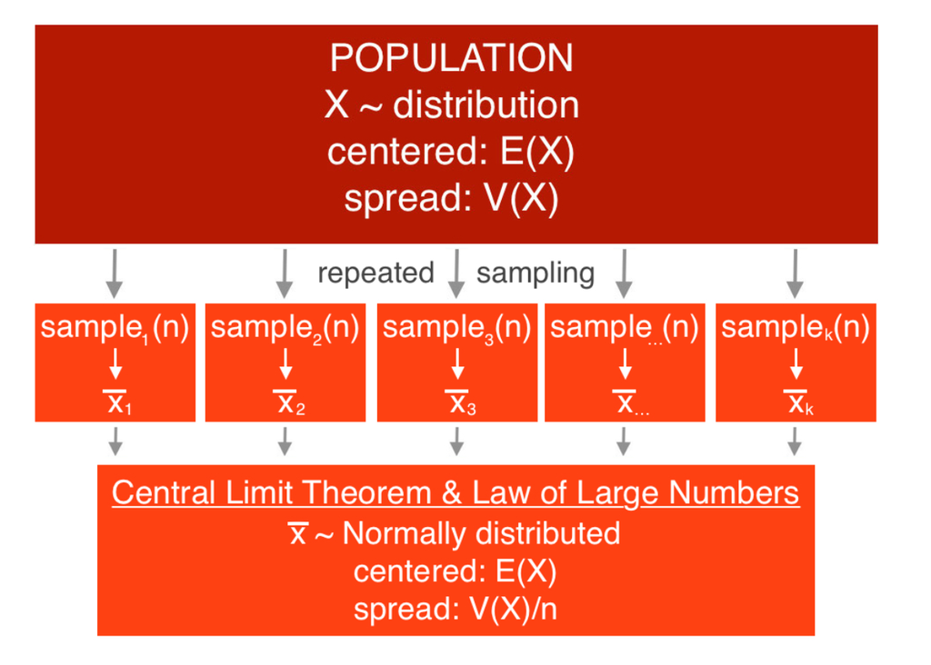

- If we drew multiple samples of 1,000 observations from a random variable and observed that the sample means were centered at 10 with variance 0.002, what would be your best guess for:
- The population mean of the original random variable?
  - 10
  - Recall, mean of $\bar{x} \approx \mathbb{E}(X)$
- The population variance of the original random variable?
  - 2
  - Recall, variance of $\bar{X} \approx \mathbb{V}(X)/n$
    - So, 0.002 $\approx \mathbb{V}(X)/1000$
      - Therefore, $\mathbb{V}(X) \approx 1000 \times 0.002 \approx 2$

## For Next Class

- Review what you learned today
- Do new set of readings:
  - We are going to examine quantifying uncertainty
  - DASS Chapter 7
    - Follow along the exercises with your own computer
- Bring your laptops to class